# Ground Elevation Source Comparison — rr

May 22, 2026

## Overview

**Site:** rr | **ECPs:** 169 (type = EVP) | **Sources evaluated:** 6

## Bias and RMSE by source

| source | n | Bias (m) | RMSE (m) | MAE (m) | pct_within_10cm | pct_within_20cm |
| --- | --- | --- | --- | --- | --- | --- |
| massgis | 169 | 0.003 | 0.044 | 0.031 | 96.4 | 100.0 |
| lidar_spring | 169 | 0.165 | 0.174 | 0.167 | 6.5 | 75.7 |
| lidar_summer | 168 | 0.221 | 0.245 | 0.221 | 7.1 | 53.0 |
| photo_spring_mica | 169 | 0.215 | 0.263 | 0.215 | 14.8 | 61.5 |
| photo_summer | 167 | 0.365 | 0.535 | 0.386 | 13.8 | 37.1 |
| photo_spring_hesai | 165 | 0.206 | 0.612 | 0.279 | 19.4 | 57.6 |

A consistent positive `mean_bias` across sources that share a common processing lineage (e.g. all project lidar and photogrammetry) but not in external reference data (MassGIS) points to a datum or reprojection issue rather than a ground-finding problem.

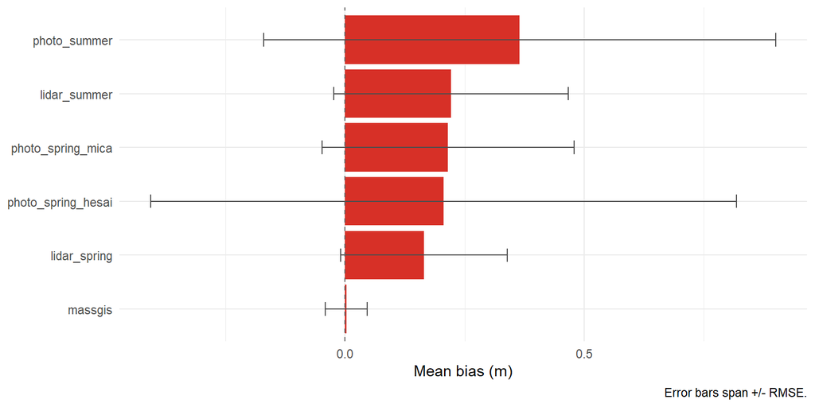

## Full metrics table

All metric columns, all sources and ECP classes.

| source | group | n | mean_bias | median_bias | mae | mad | rmse | max_abs | q25_abs | q75_abs | q95_abs | slope | bias_p | pct_within_10cm | pct_within_20cm |
| --- | --- | --- | --- | --- | --- | --- | --- | --- | --- | --- | --- | --- | --- | --- | --- |
| massgis | overall | 169 | 0.003 | -0.001 | 0.031 | 0.035 | 0.044 | 0.173 | 0.012 | 0.040 | 0.084 | 0.928 | 0.411 | 96.4 | 100.0 |
| lidar_spring | overall | 169 | 0.165 | 0.162 | 0.167 | 0.049 | 0.174 | 0.332 | 0.133 | 0.197 | 0.256 | 0.958 | 0.000 | 6.5 | 75.7 |
| photo_spring_hesai | overall | 165 | 0.206 | 0.155 | 0.279 | 0.156 | 0.612 | 6.543 | 0.119 | 0.290 | 0.685 | 0.227 | 0.000 | 19.4 | 57.6 |
| photo_spring_mica | overall | 169 | 0.215 | 0.181 | 0.215 | 0.082 | 0.263 | 1.047 | 0.135 | 0.244 | 0.463 | 1.133 | 0.000 | 14.8 | 61.5 |
| lidar_summer | overall | 168 | 0.221 | 0.192 | 0.221 | 0.083 | 0.245 | 0.586 | 0.147 | 0.277 | 0.435 | 0.737 | 0.000 | 7.1 | 53.0 |
| photo_summer | overall | 167 | 0.365 | 0.258 | 0.386 | 0.221 | 0.535 | 2.300 | 0.156 | 0.513 | 1.048 | 0.740 | 0.000 | 13.8 | 37.1 |
| massgis | 1 | 26 | 0.014 | 0.025 | 0.038 | 0.029 | 0.047 | 0.138 | 0.020 | 0.050 | 0.076 | 0.971 | 0.120 | 96.2 | 100.0 |
| lidar_spring | 1 | 26 | 0.181 | 0.186 | 0.187 | 0.039 | 0.191 | 0.257 | 0.162 | 0.219 | 0.232 | 0.881 | 0.000 | 3.8 | 53.8 |
| photo_spring_mica | 1 | 26 | 0.230 | 0.228 | 0.230 | 0.046 | 0.236 | 0.384 | 0.195 | 0.257 | 0.331 | 0.714 | 0.000 | 0.0 | 26.9 |
| lidar_summer | 1 | 26 | 0.365 | 0.388 | 0.365 | 0.113 | 0.383 | 0.586 | 0.289 | 0.440 | 0.523 | 0.474 | 0.000 | 3.8 | 7.7 |
| photo_spring_hesai | 1 | 26 | 0.471 | 0.247 | 0.474 | 0.067 | 1.306 | 6.543 | 0.199 | 0.278 | 0.367 | -4.291 | 0.065 | 11.5 | 30.8 |
| photo_summer | 1 | 26 | 0.514 | 0.502 | 0.514 | 0.201 | 0.542 | 0.863 | 0.380 | 0.635 | 0.777 | 0.297 | 0.000 | 0.0 | 0.0 |
| massgis | 10 | 1 | -0.088 | -0.088 | 0.088 | 0.000 | 0.088 | 0.088 | 0.088 | 0.088 | 0.088 | NA | NA | 100.0 | 100.0 |
| photo_spring_mica | 10 | 1 | 0.032 | 0.032 | 0.032 | 0.000 | 0.032 | 0.032 | 0.032 | 0.032 | 0.032 | NA | NA | 100.0 | 100.0 |
| lidar_spring | 10 | 1 | 0.076 | 0.076 | 0.076 | 0.000 | 0.076 | 0.076 | 0.076 | 0.076 | 0.076 | NA | NA | 100.0 | 100.0 |
| photo_spring_hesai | 10 | 1 | 0.085 | 0.085 | 0.085 | 0.000 | 0.085 | 0.085 | 0.085 | 0.085 | 0.085 | NA | NA | 100.0 | 100.0 |
| lidar_summer | 10 | 1 | 0.094 | 0.094 | 0.094 | 0.000 | 0.094 | 0.094 | 0.094 | 0.094 | 0.094 | NA | NA | 100.0 | 100.0 |
| photo_summer | 10 | 1 | 0.181 | 0.181 | 0.181 | 0.000 | 0.181 | 0.181 | 0.181 | 0.181 | 0.181 | NA | NA | 0.0 | 100.0 |
| massgis | 11 | 8 | 0.091 | 0.094 | 0.091 | 0.107 | 0.115 | 0.173 | 0.019 | 0.158 | 0.170 | 0.370 | 0.012 | 50.0 | 100.0 |
| lidar_spring | 11 | 8 | 0.241 | 0.258 | 0.241 | 0.067 | 0.248 | 0.312 | 0.192 | 0.286 | 0.306 | 1.154 | 0.000 | 0.0 | 25.0 |
| lidar_summer | 11 | 8 | 0.294 | 0.302 | 0.294 | 0.107 | 0.301 | 0.394 | 0.227 | 0.337 | 0.387 | 0.950 | 0.000 | 0.0 | 0.0 |
| photo_spring_mica | 11 | 8 | 0.307 | 0.317 | 0.307 | 0.113 | 0.325 | 0.450 | 0.248 | 0.394 | 0.435 | 0.954 | 0.000 | 12.5 | 12.5 |
| photo_spring_hesai | 11 | 8 | 0.394 | 0.398 | 0.394 | 0.191 | 0.439 | 0.702 | 0.296 | 0.513 | 0.657 | 0.470 | 0.001 | 12.5 | 12.5 |
| photo_summer | 11 | 8 | 1.017 | 0.926 | 1.017 | 0.580 | 1.212 | 2.300 | 0.547 | 1.285 | 2.080 | -10.779 | 0.005 | 12.5 | 12.5 |
| massgis | 12 | 8 | 0.013 | 0.009 | 0.032 | 0.027 | 0.041 | 0.073 | 0.010 | 0.057 | 0.071 | 0.488 | 0.404 | 100.0 | 100.0 |
| lidar_spring | 12 | 8 | 0.181 | 0.161 | 0.181 | 0.057 | 0.193 | 0.332 | 0.138 | 0.206 | 0.292 | 0.233 | 0.000 | 0.0 | 62.5 |
| lidar_summer | 12 | 8 | 0.229 | 0.228 | 0.229 | 0.079 | 0.239 | 0.344 | 0.178 | 0.271 | 0.330 | 0.550 | 0.000 | 0.0 | 37.5 |
| photo_spring_mica | 12 | 8 | 0.444 | 0.391 | 0.444 | 0.290 | 0.536 | 1.047 | 0.204 | 0.508 | 0.959 | -3.434 | 0.006 | 0.0 | 25.0 |
| photo_spring_hesai | 12 | 7 | 0.539 | 0.398 | 0.552 | 0.598 | 0.813 | 1.860 | 0.124 | 0.675 | 1.551 | 2.813 | 0.073 | 28.6 | 28.6 |
| photo_summer | 12 | 8 | 1.053 | 1.257 | 1.148 | 0.590 | 1.299 | 2.172 | 0.679 | 1.531 | 1.964 | -7.038 | 0.008 | 0.0 | 0.0 |

[output cut: 54 more lines]

## Predicted vs. observed by source

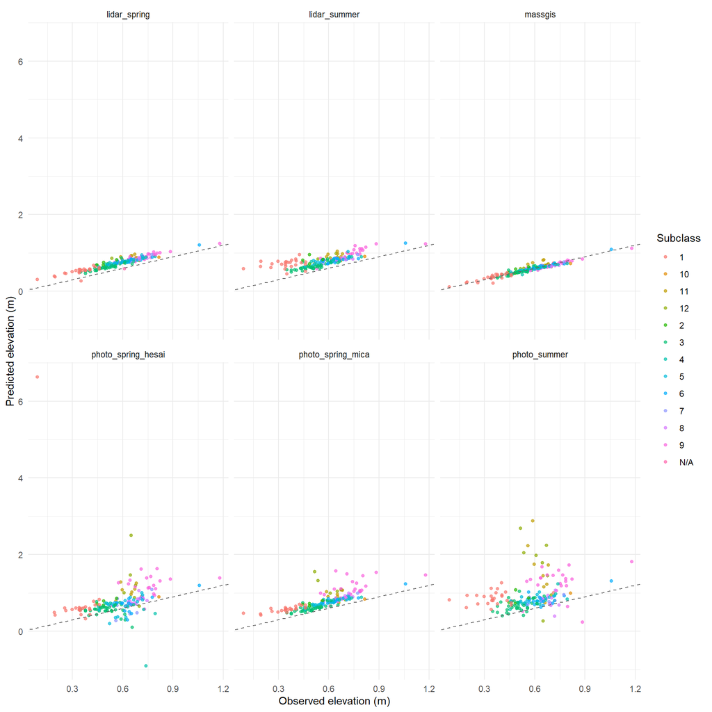

## Bias correction

The results above suggest a systematic bias in the UAS-based data sources, possibly a datum shift or other projection issue. This apparent bias swamps other sources of error and makes comparison difficult. The plots and tables here use data with the per-source bias removed.

### Summary stats by source after bias correction

| source | n | Bias (m) | RMSE (m) | MAE (m) | pct_within_10cm | pct_within_20cm |
| --- | --- | --- | --- | --- | --- | --- |
| massgis | 169 | 0 | 0.044 | 0.032 | 96.4 | 100.0 |
| lidar_spring | 169 | 0 | 0.054 | 0.040 | 94.1 | 99.4 |
| lidar_summer | 168 | 0 | 0.105 | 0.083 | 70.2 | 93.5 |
| photo_spring_mica | 169 | 0 | 0.152 | 0.098 | 67.5 | 92.9 |
| photo_summer | 167 | 0 | 0.391 | 0.272 | 20.4 | 51.5 |
| photo_spring_hesai | 165 | 0 | 0.576 | 0.220 | 48.5 | 73.3 |

### DTM/DEM elevation vs ground truth after bias correction

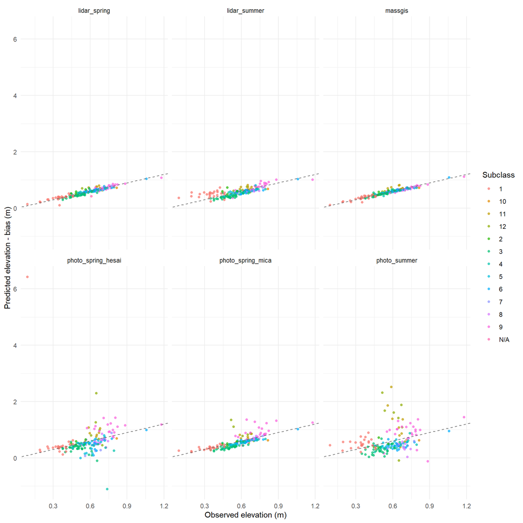

## Per-source diagnostic plots

Using the original, biased data.

### lidar_spring

**Predicted vs observed**

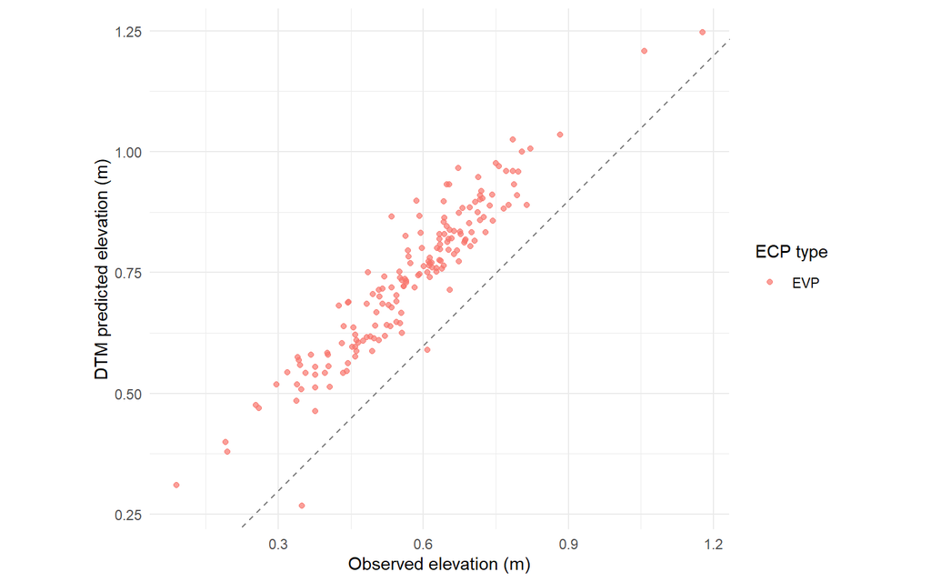

**Residual histogram**

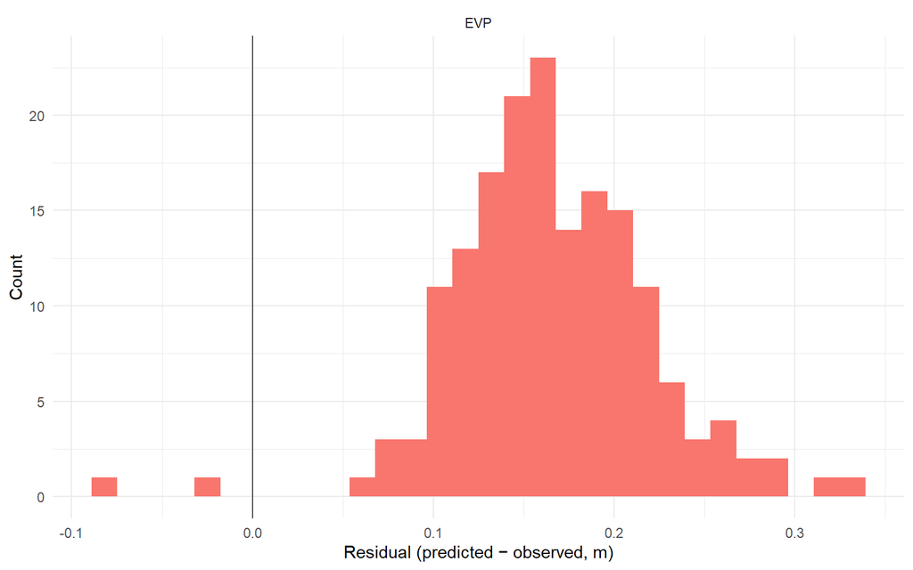

**Residual map**

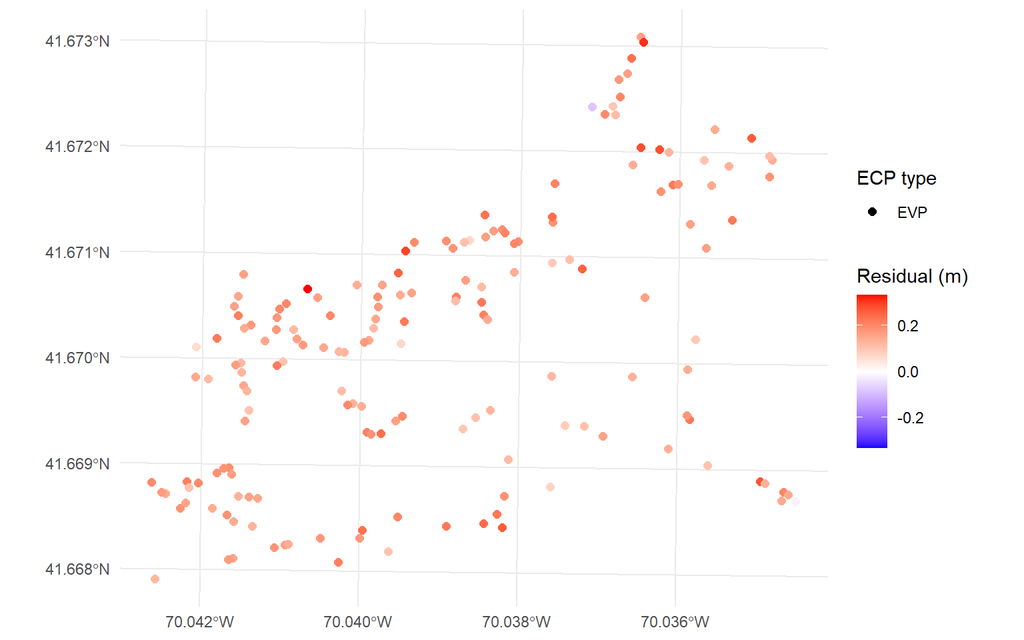

**Residual vs elevation**

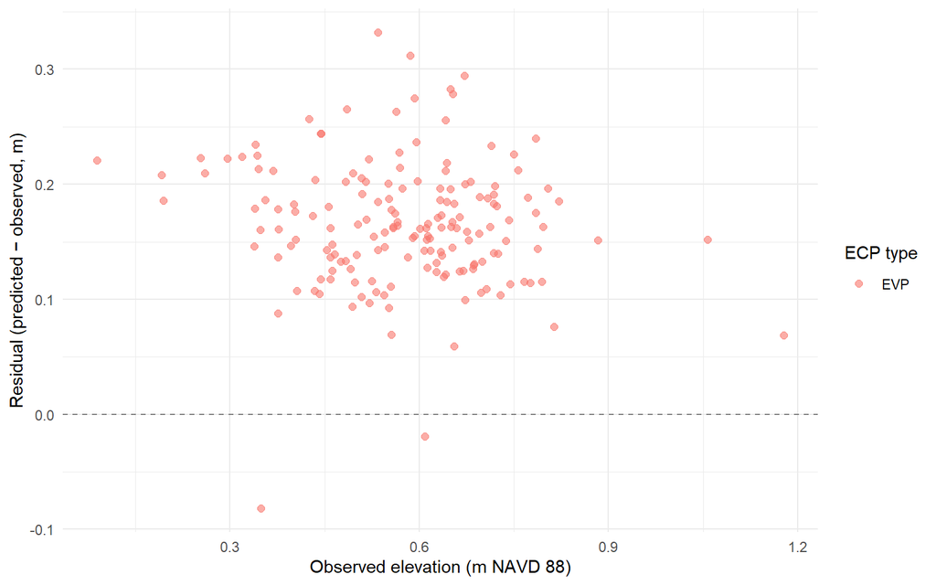

**Q-Q plot**

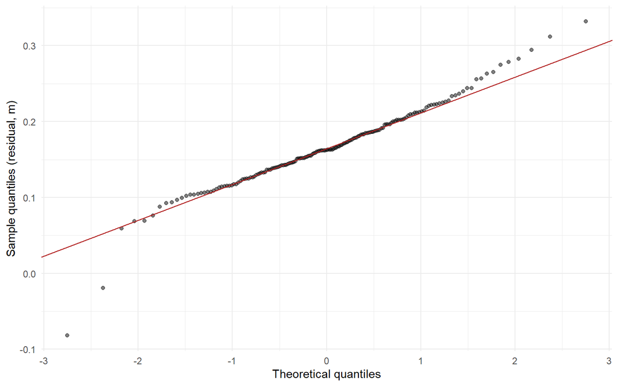

### lidar_summer

**Predicted vs observed**

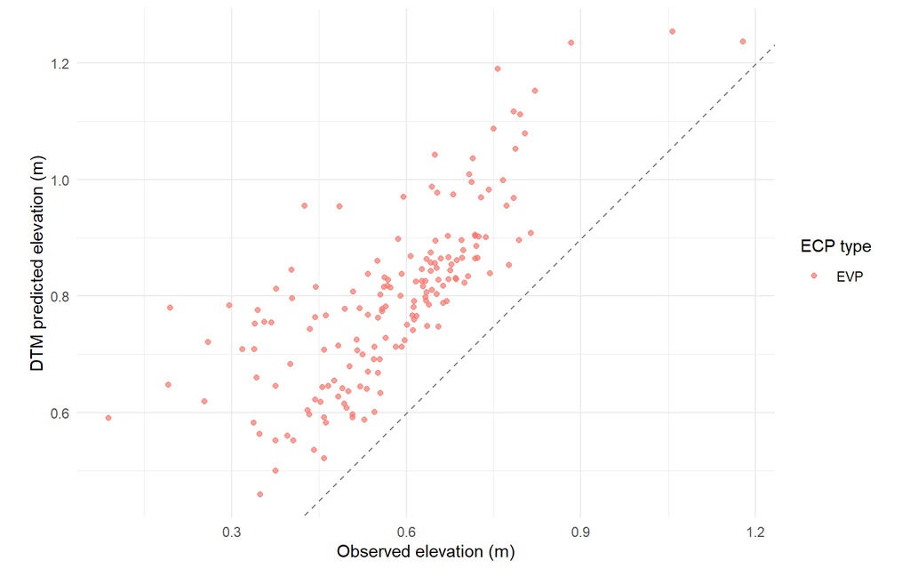

**Residual histogram**

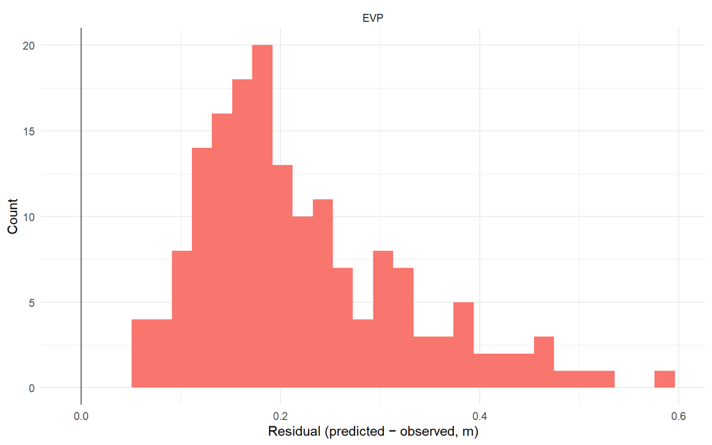

**Residual map**

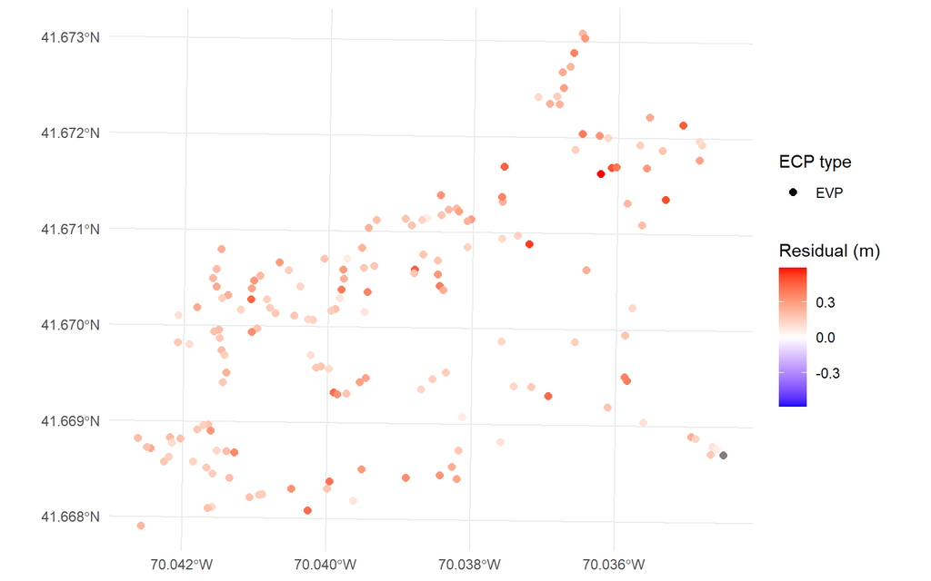

**Residual vs elevation**

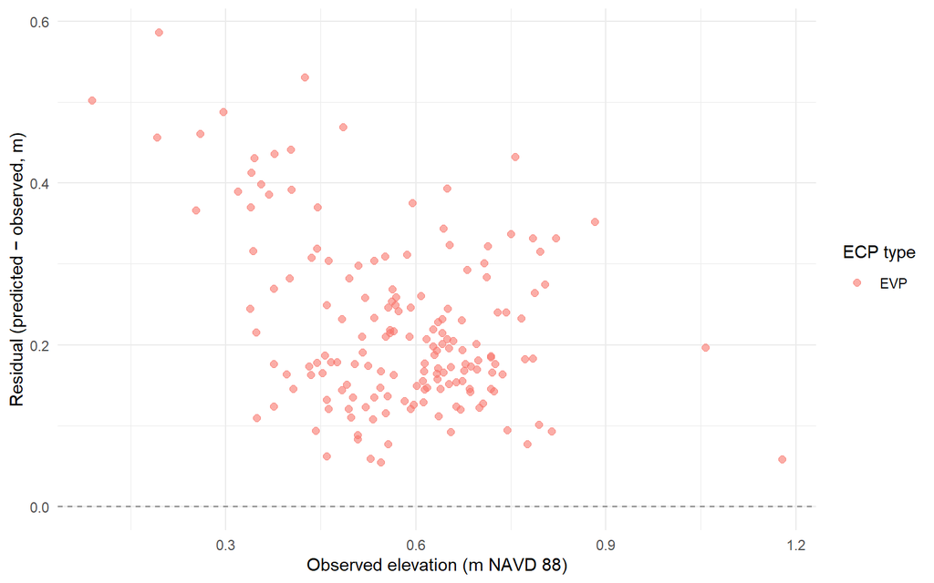

**Q-Q plot**

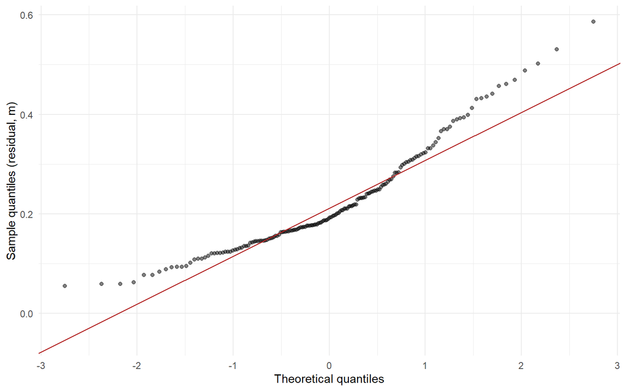

### photo_spring_hesai

**Predicted vs observed**

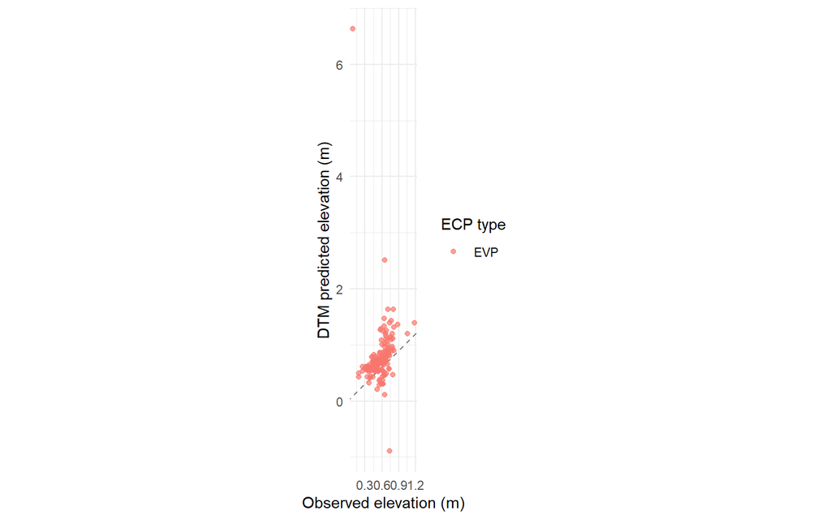

**Residual histogram**

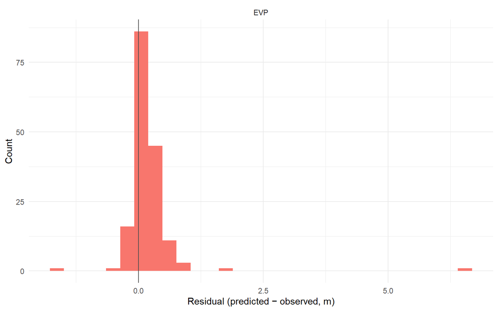

**Residual map**

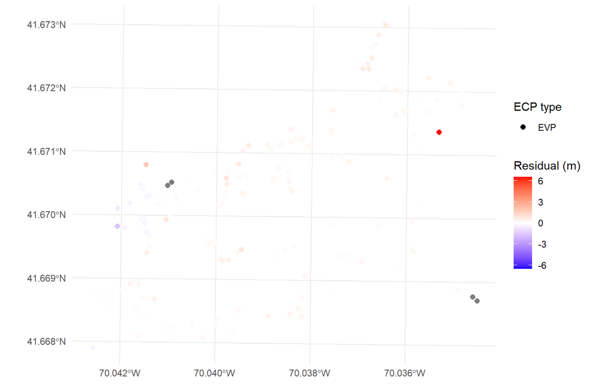

**Residual vs elevation**

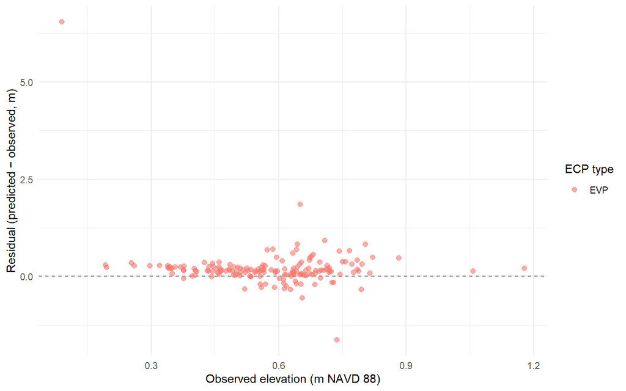

**Q-Q plot**

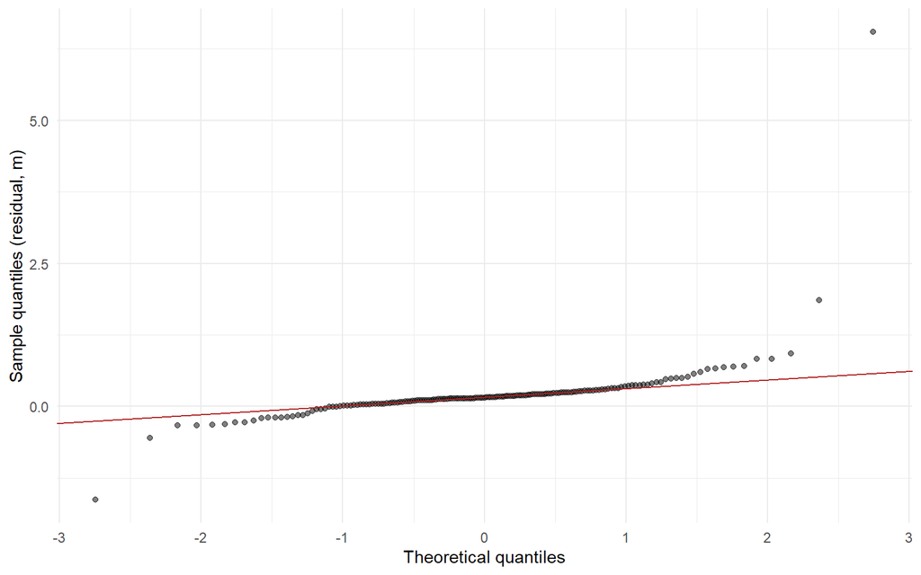

### photo_spring_mica

**Predicted vs observed**

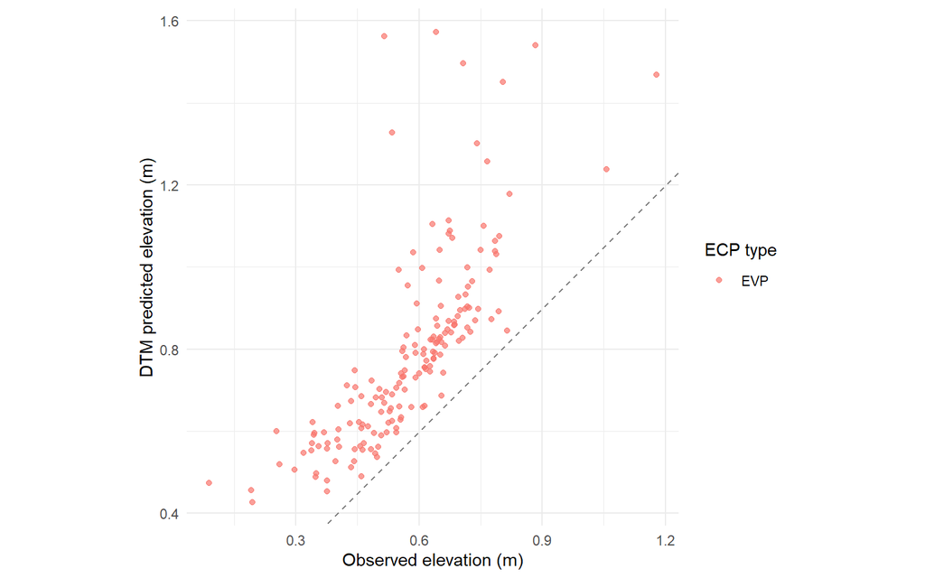

**Residual histogram**

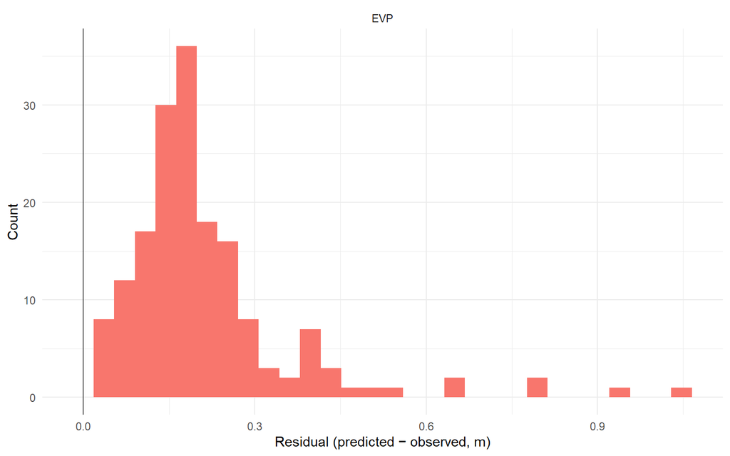

**Residual map**

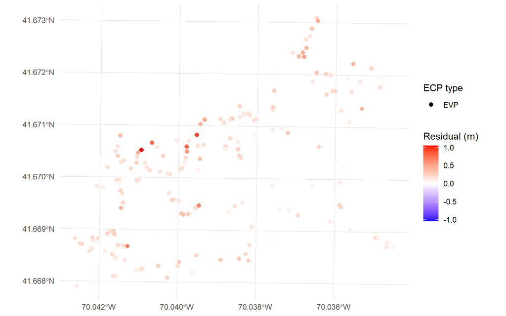

**Residual vs elevation**

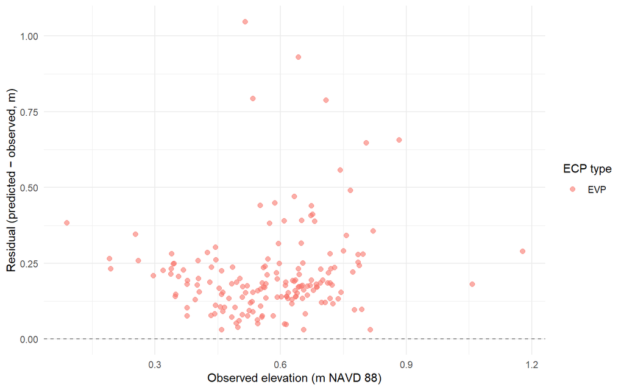

**Q-Q plot**

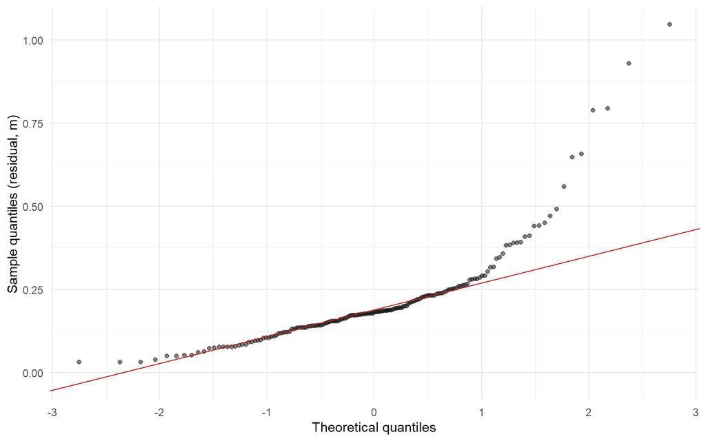

### photo_summer

**Predicted vs observed**

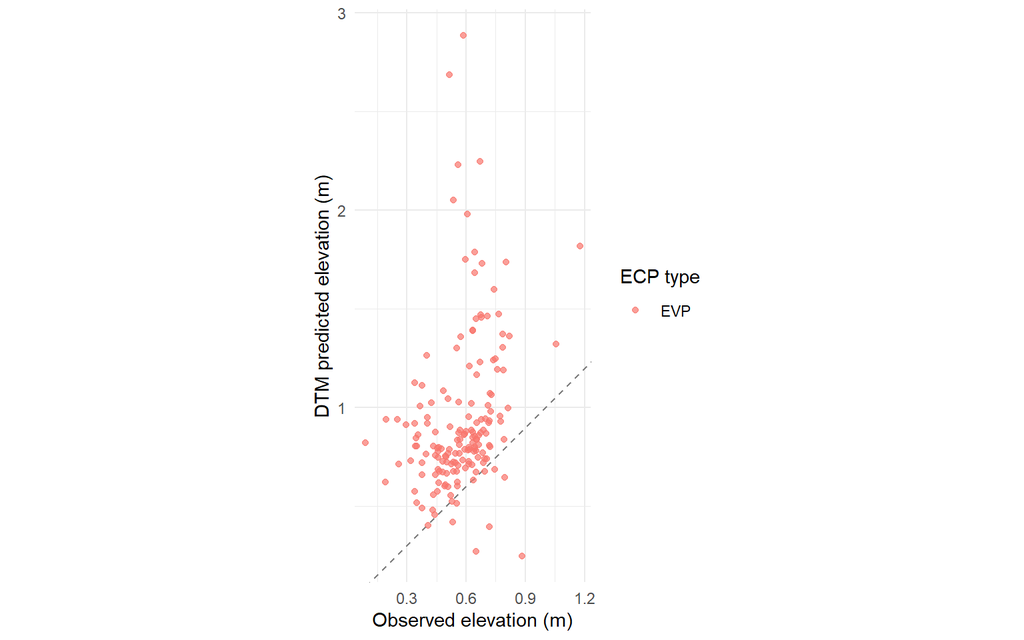

**Residual histogram**

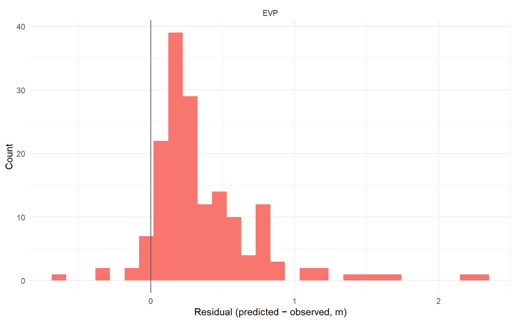

**Residual map**

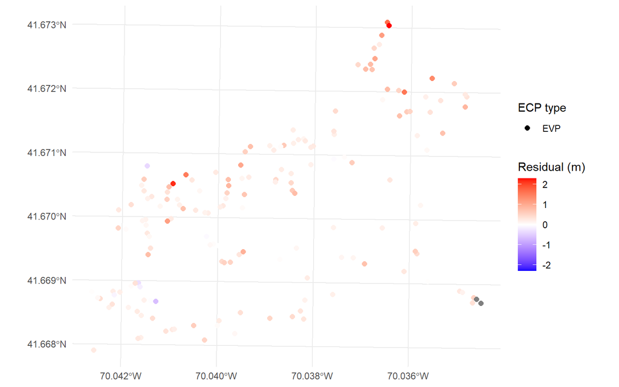

**Residual vs elevation**

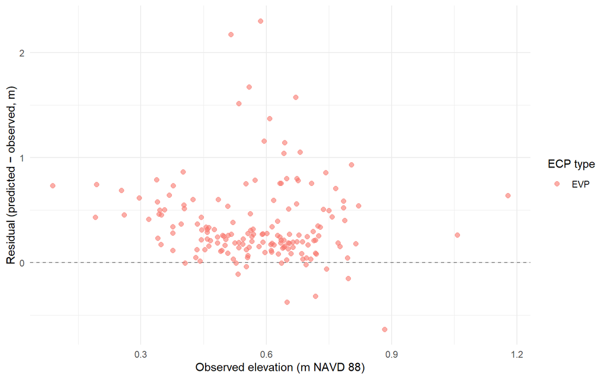

**Q-Q plot**

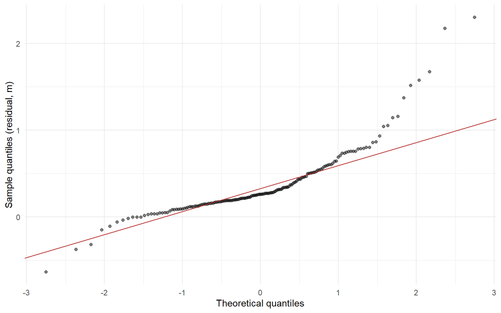